# Parsimony Analysis of DNA

Ruth Walters

2026-02-05

## Import dependencies

```r
library(phangorn)
library(ape)
```

```r
BiocManager::install("msa")
library(msa)
```

## Load data from the previous exercise

```r
primate <- read.delim("data/data.txt")
```

```r
primate_df <- data.frame(primate[,2:11], row.names = primate[,1])
primate.mat <- as.matrix(primate_df)
levels <- c("0", "1", "2", "3")
primate.phy <- phyDat(primate.mat, type = "USER", levels = levels)
```

```r
dm <- dist.hamming(primate.phy)
treeUPGMA <- upgma(dm)
```

```r
tree <- optim.parsimony(treeUPGMA, primate.phy)
```

```
## Final p-score 21 after  1 nni operations
```

```r
tree_parsimony <- root(tree,
                       outgroup = "ringtailed_lemur",
                       resolve.root = TRUE)
```

## Load the FASTA file

```r
seqs <- readDNAStringSet("data/primates.raw.fasta")

seqs
```

```
## DNAStringSet object of length 7:
##     width seq                                               names
## [1]  1044 ATTAATCCCCTGGCCCAACCCGT...CTTTTATACTAATAATCTTA--- humans
## [2]  1044 ATTAACCCCCTAGCCCAACCCAT...CCTTCATACTAATAATCTTA--- chimpanzee
## [3]  1044 ATTAACCCCCTGGCCCAACCCAT...CCTTCATACTAATAGTTCTATAG gorilla
## [4]  1044 ATCAACCCTCTAGCCCACCTTAT...CACTAATACTAATAATCT----- howler_monkey
## [5]  1044 ATAAAACCTATTATCCTAATATT...CAGCCCTACTAACCCTAAACTAG ringtailed_lemur
## [6]  1044 ATCAACCCCCTAGCCCAACCTAT...CACTCACATTCCCTGCCCCATA- gibbon
## [7]  1044 ATTAACCCACTAGCTCAACCCAT...CCCTACTCTTAACCCTTCACT-- rhesus_monkey
```

```r
primate.aligned <- msa(seqs,
                       method = "Muscle")

primate.aligned
```

```
## MUSCLE 3.8.31
##
## Call:
##    msa(seqs, method = "Muscle")
##
## MsaDNAMultipleAlignment with 7 rows and 1046 columns
##     aln                                                    names
## [1] ATAAAACCTATTATCCTAATATTTAT...ACCAGCCCTACTAACCCTAAACTAG ringtailed_lemur
## [2] ATCAACCCTCTAGCCCACCTTATTAT...CCCACTAATACTAATAATCTNNNNN howler_monkey
## [3] ATTAACCCACTAGCTCAACCCATTAT...CCCCCTACTCTTAACCCTTCACTNN rhesus_monkey
## [4] ATCAACCCCCTAGCCCAACCTATCAT...TCCACTCACATTCCCTGCCCCATAN gibbon
## [5] ATTAACCCCCTGGCCCAACCCATCAT...CCCCTTCATACTAATAGTTCTATAG gorilla
## [6] ATTAATCCCCTGGCCCAACCCGTCAT...CCCTTTTATACTAATAATCTTANNN humans
## [7] ATTAACCCCCTAGCCCAACCCATCAT...CCCCTTCATACTAATAATCTTANNN chimpanzee
## Con ATTAACCCCCTAGCCCAACCCATCAT...CCC??TCATACTAATA?TC??ATNN Consensus
```

**Question 1**: While there are only 2 gaps visible, there are several mismatches visible. This suggests that gaps were penalized more heavily than mismatches.

```r
primate.aligned.convert <- as.DNAbin(primate.aligned)

write.FASTA(primate.aligned.convert,
            file = "data/primate.raw.aligned.fasta")
```

## Parsimony analysis

```r
primates <- read.phyDat("data/primate.raw.aligned.fasta",
                        format = "fasta")

primates
```

```
## 7 sequences with 1046 character and 301 different site patterns.
## The states are a c g t
```

```r
tree <- optim.parsimony(treeUPGMA, primates)
```

```
## Final p-score 976 after  5 nni operations
```

**Question 2**: p-score is 976 after 5 nni operations

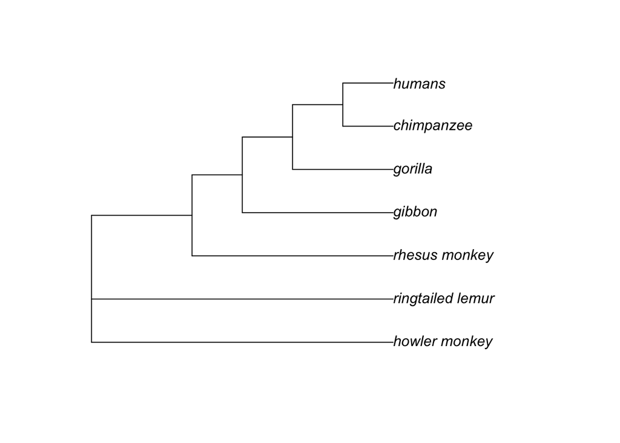

```r
plot.phylo(tree)
```

```r
tree.rooted <- root(tree,
                    outgroup = "ringtailed_lemur",
                    resolve.root = TRUE)
```

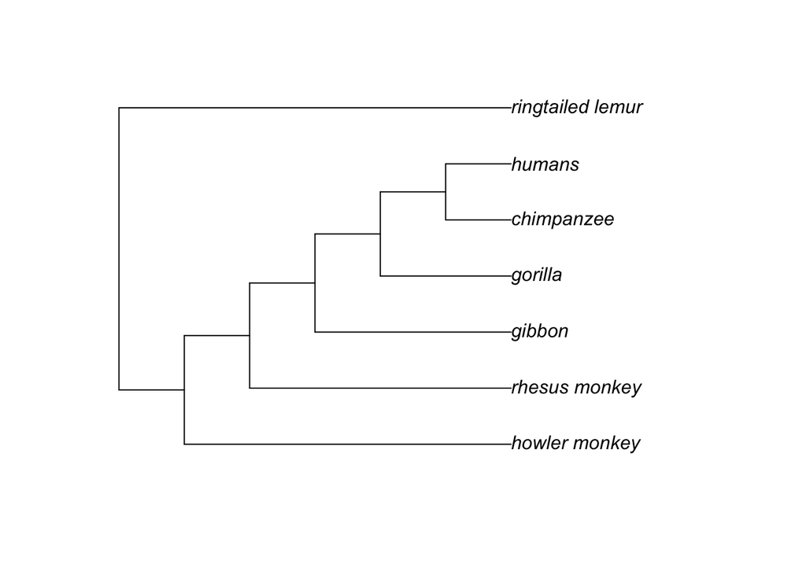

```r
plot.phylo(tree.rooted)
```

**Question 4**: The character that we are examining today is nucleotide sequence, and the associated character states is the nucleotide base (A/T/G/C) present at a specific site in the genome. These character states won’t change across organisms like plants because all organisms on earth retain the same nucleotide bases.

**Question 5**: No, my tree looks the same as everyone else in the room. This occurs because we were using the same genomes to preform the alignment and essentially comparing the exact same characteristics.

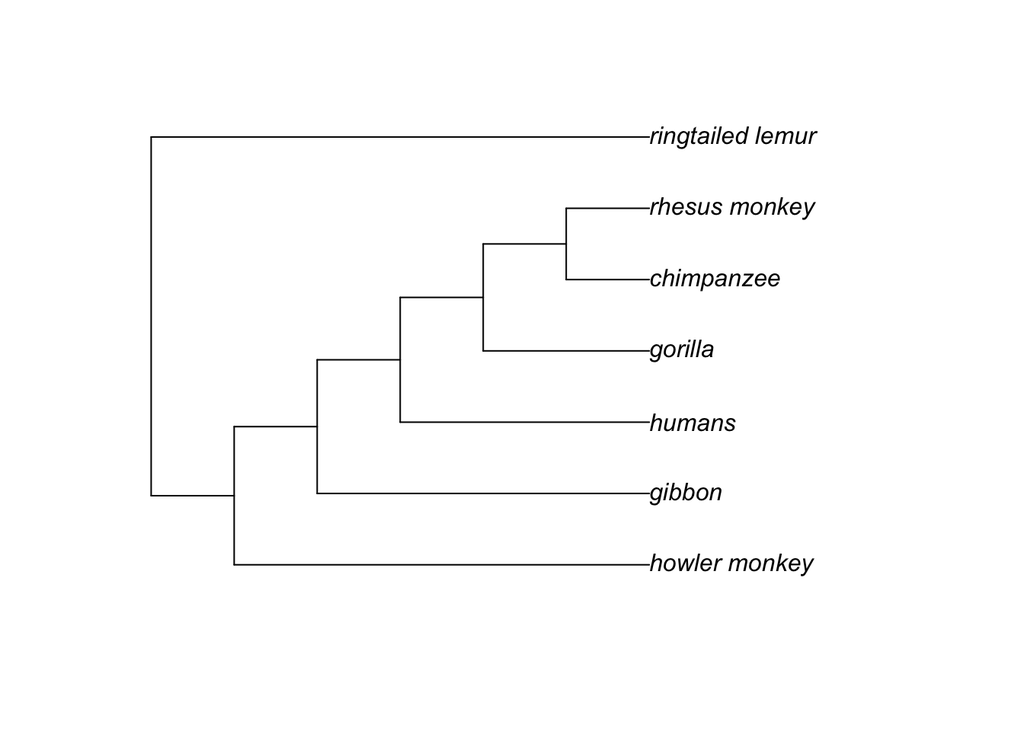

```r
plot.phylo(tree_parsimony)
```

**Question 6**: My tree based on morphology suggests that rhesus monkeys are more closely related to chimpanzees, and implicitly places humans closer to great apes than the primates. The gene-based phylogeny is able to more accurately capture the evolution from monkeys to apes to primates.

**Question 7**: Gene-based phylogenies seem more accurate/objective than character-based phylogenies. One reason for this might be because character-based phylogenies are vulnerable to biases like size (for example, humans might be classed as more closely related to larger organisms than chimpanzees) while gene alignments are not sensitive to this.